# Ready, Set, Go: A Data Wrangling Tutorial Using Vehicles Dataset

Hadear Rizq

3/30/26

```r
# Load any R Packages you may need
library(tidyverse)
library(mosaic)
library(fueleconomy)
```

# Introduction

Data Wrangling is the process of turning raw data into something easier to analyze. Without data wrangling, raw data is messy, incomplete, and difficult to understand.

In this tutorial, we will explore the fuel economy data using the fueleconomy package. By the end of this tutorial, you will understand how to manipulate/organize data. We will be taking a close look at the vehicle’s data set, which shows the fuel economy data from the EPA, 1985–2015.

# Step 1: Verb Name Functions

```r
vehicles_clean <- vehicles %>%
  filter(year >= 2000) %>%
  select(id, make, model, year, class, fuel, cyl, hwy, cty) %>%
  arrange(year)

head(vehicles_clean)
```

```
## # A tibble: 6 × 9
##      id make  model    year class           fuel      cyl   hwy   cty
##   <dbl> <chr> <chr>   <dbl> <chr>           <chr>   <dbl> <dbl> <dbl>
## 1 15871 Acura 3.2TL    2000 Midsize Cars    Premium     6    27    17
## 2 15872 Acura 3.5RL    2000 Midsize Cars    Premium     6    22    16
## 3 15640 Acura Integra  2000 Subcompact Cars Regular     4    28    21
## 4 15641 Acura Integra  2000 Subcompact Cars Regular     4    28    22
## 5 15642 Acura Integra  2000 Subcompact Cars Premium     4    28    22
## 6 15589 Acura NSX      2000 Two Seaters     Premium     6    22    15
```

Data sets sometimes have a lot of information, more than what you need to make an analysis. The ‘select’ function allows you to choose which column to keep. The ‘filter’ function is similar, but only applies to the rows that meet certain conditions. Then, ‘arrange’ is a function that sorts rows in a meaningful order. I use them all together with a pipeline operator, ’%>%, because it is more visually appealing than having it all nested.

I used all the functions mentioned above to filter out all models from 2000 onwards. I selected the 9 variables that I found to be important to my analysis and arranged them by year.

# Step 2: Cleaning

## Finding Mistakes

One way to find mistakes is by looking for suspicious outputs, which can be identified by consistently summarizing your data.

```r
summary(vehicles_clean)
```

```
##        id            make              model                year
##  Min.   :15589   Length:16649       Length:16649       Min.   :2000
##  1st Qu.:19754   Class :character   Class :character   1st Qu.:2004
##  Median :24086   Mode  :character   Mode  :character   Median :2008
##  Mean   :24881                                         Mean   :2007
##  3rd Qu.:30728                                         3rd Qu.:2011
##  Max.   :34932                                         Max.   :2015
##
##     class               fuel                cyl              hwy
##  Length:16649       Length:16649       Min.   : 2.000   Min.   : 11.00
##  Class :character   Class :character   1st Qu.: 4.000   1st Qu.: 20.00
##  Mode  :character   Mode  :character   Median : 6.000   Median : 24.00
##                                        Mean   : 5.961   Mean   : 24.49
##                                        3rd Qu.: 8.000   3rd Qu.: 28.00
##                                        Max.   :16.000   Max.   :109.00
##                                        NA's   :49
##       cty
##  Min.   :  7.00
##  1st Qu.: 15.00
##  Median : 17.00
##  Mean   : 17.88
##  3rd Qu.: 20.00
##  Max.   :138.00
##
```

I noticed when looking at the summary of the data set that there are a couple of things that I found suspicious. - cyl has 49 missing values - hwy has a suspiciously high maximum of 109 MPG - cty has an even more extreme maximum of 138 MPG

## Detecting with Outliers

**Univariate outlier** is an observation whose location is inconsistent with the pattern exhibited by the rest of the data. We will be finding outliers using the **IQR method**.

Lower fence:𝑄1 − 1.5 ∗ (𝑄3 − 𝑄1) Upper fence:𝑄3 + 1.5 ∗ (𝑄3 − 𝑄1)

```r
hwy_summary <- favstats(~hwy, data = vehicles_clean)

lf_hwy <- hwy_summary$Q1 - 1.5 * (hwy_summary$Q3 - hwy_summary$Q1)
uf_hwy <- hwy_summary$Q3 + 1.5 * (hwy_summary$Q3 - hwy_summary$Q1)

lf_hwy
```

```
## [1] 8
```

```r
uf_hwy
```

```
## [1] 40
```

```r
cty_summary <- favstats(~cty, data = vehicles_clean)

lf_cty <- cty_summary$Q1 - 1.5 * (cty_summary$Q3 - cty_summary$Q1)
uf_cty <- cty_summary$Q3 + 1.5 * (cty_summary$Q3 - cty_summary$Q1)

lf_cty
```

```
## [1] 7.5
```

```r
uf_cty
```

```
## [1] 27.5
```

Both the hwy and cty upper fences show that there are outliers. For uf_hwy, it states that if the value is above 40, it is considered an outlier. The summary shows that the maximum is 109. The same applies to uf_cty; if it is above 27.5, it is considered an outlier, and the maximum is 138. However, since I can’t verify that the outlier was a mistake, like a typo, I will analyze with the outlier.

**Always report if you had an outlier in your data**

# Step 3: Missing Data

Missing data is when there is no data stored for a variable in an observation. Although common it can have a very detrimental effect on the data analysis. It is shown as empty or null values in the data set.

## Find Missing Data

```r
#another way of finding missing data other than using summary
missing <-is.na(vehicles_clean$cyl)
sum(missing)
```

```
## [1] 49
```

```r
#we can identify which rows too
which(is.na(vehicles_clean$cyl))
```

```
##  [1]   323   324   757  1154  1193  1665  2083  2632  3676 11883 12629 12742
## [13] 12743 12955 12956 13064 13194 13286 13719 13763 13931 13962 14239 14368
## [25] 14418 14470 14570 14925 14966 15054 15063 15064 15104 15105 15106 15138
## [37] 15421 15525 15599 15653 15746 16136 16177 16296 16297 16322 16323 16355
## [49] 16617
```

### Handling Missing Data

There are three main ways of handling missing data:

- Listwise deletion - Categorical
  - Remove every row with at least one missing value
  - Not usually the best way to handle data
- Pairwise deletion - Categorical
  - Removes missing values only from the variables in your analysis
- Imputation - Quantitative
  - mean imputation: Replaces the missing data with the mean of the existing data
  - regression imputation: Replace the missing data using the regression method

#### Listwise deletion

Since cyl is categorical I will be using listwise deletion to remove every (row) with at least one missing value

```r
vehicles_clean = na.omit(vehicles_clean)
```

# Step 4: Data Graphic

## Count Vehicles by Class

The count() function is used to count the occurance of unique values of one or more varibles in a data set.

```r
vehicles_clean %>%
  count(class)%>%
  arrange(desc(n))
```

```
## # A tibble: 26 × 2
##    class                           n
##    <chr>                       <int>
##  1 Compact Cars                 2422
##  2 Midsize Cars                 2009
##  3 Sport Utility Vehicle - 4WD  2000
##  4 Sport Utility Vehicle - 2WD  1547
##  5 Subcompact Cars              1480
##  6 Two Seaters                  1001
##  7 Large Cars                    988
##  8 Standard Pickup Trucks 2WD    823
##  9 Minicompact Cars              742
## 10 Small Station Wagons          723
## # ℹ 16 more rows
```

Using count in this data set allows us to see how many vehicles fall into each class. It allows us to see which categories are most common in the data set. I added arrange(desc(n)) to show us the classes with the highest count to the least. Turns out that Compact Cars come out to be the highest count.

## Visualization: Average Miles Per Gallon (MPG) vs. Number of Cylinders

Cylinders are vital parts of the engine, it is a chamber where fuel is combusted and power is generated. The more cylinders your engine has the more power is produced. if more power is produced it mean that it will use more fuel.

```r
cyl_summary = vehicles_clean %>%
  group_by(cyl)%>%
  summarize(avg_hwy = mean(hwy), avg_cty = mean(cty))
cyl_summary
```

```
## # A tibble: 9 × 3
##     cyl avg_hwy avg_cty
##   <dbl>   <dbl>   <dbl>
## 1     2    22.4    16
## 2     3    46.1    38.6
## 3     4    29.4    22.2
## 4     5    25.3    18.0
## 5     6    23.5    16.7
## 6     8    19.3    13.7
## 7    10    18      11.5
## 8    12    17.1    10.9
## 9    16    14.6     8
```

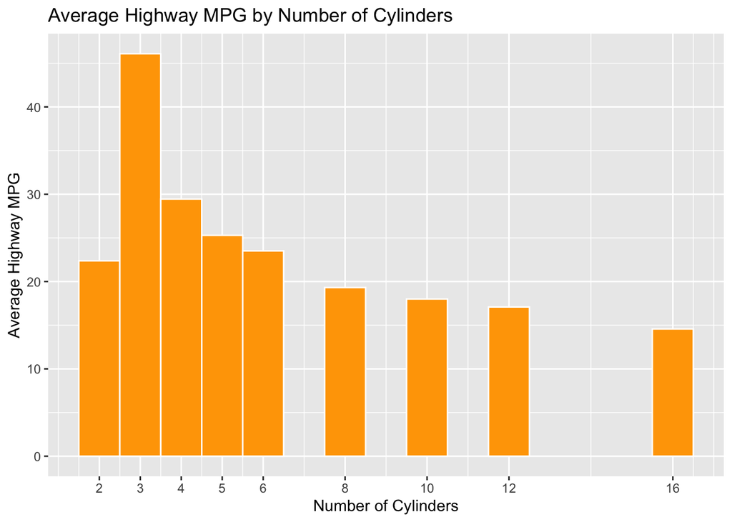

```r
ggplot(cyl_summary, aes(x = cyl, y = avg_hwy))+
  geom_col(color="white",fill="orange", width = 1)+
  labs(title = "Average Highway MPG by Number of Cylinders",
       x = "Number of Cylinders",
       y = "Average Highway MPG")+
  scale_x_continuous(breaks = c(2,3,4,5,6,8,10,12,16))
```

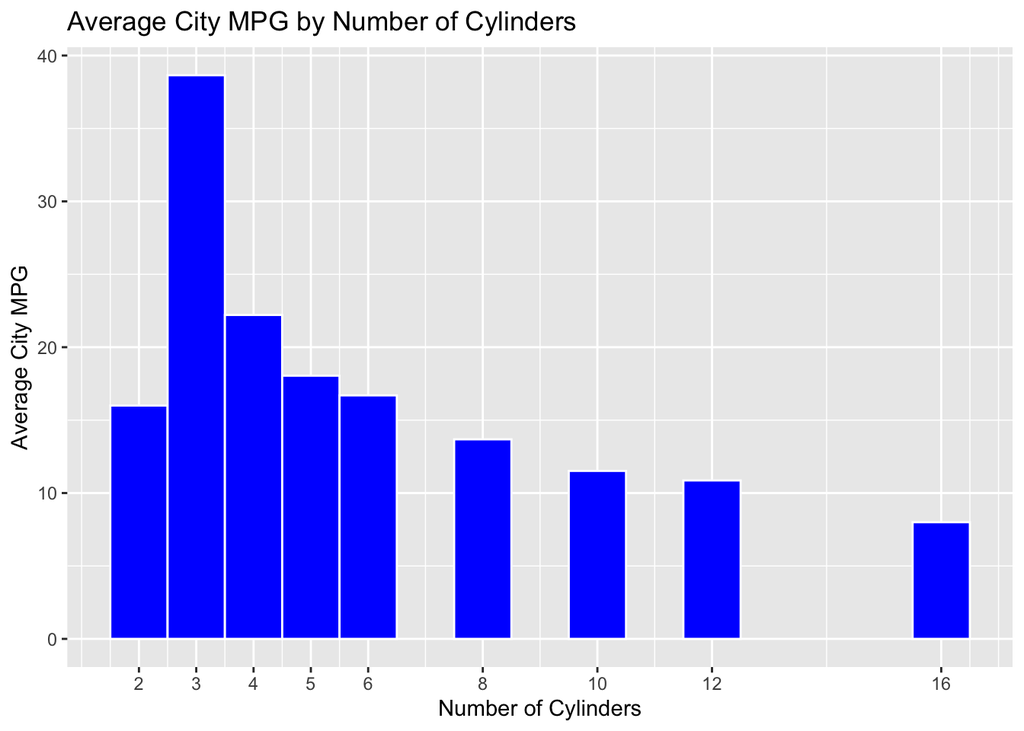

```r
ggplot(cyl_summary, aes(x = cyl, y = avg_cty))+
  geom_col(color="white",fill="blue", width = 1)+
  labs(title = "Average City MPG by Number of Cylinders",
       x = "Number of Cylinders",
       y = "Average City MPG")+
  scale_x_continuous(breaks = c(2,3,4,5,6,8,10,12,16))
```

I am a surprised with the results especially with cylinder 3 having such a high miles per gallon average. Which might be due to the outliers in the data that I mentioned before. However besides I think my hypothesis was nearly right, the more cylinders the more fuel the less miles per gallon. I also notices that the highway is a bit higher in MPG, which I predict is due to being able to go at faster speeds and less stops compared to driving in the city.